# Week 20181009

_jas

20181012

# Tidy tuesday challenge: Week 2018-10-09: Voter turnout data

## keep it simple:

### Objectives:

- work on data,
- practice,
- get better on your workflow,
- get better on your skills: import, tidy , understand( transform, visualize,model ) , communicate

https://rviews.rstudio.com/2017/06/08/what-is-the-tidyverse/

### this week expected

well its kind of friday so … just one thing:

- use the faceted maps through geofacet

http://ryanhafen.com/blog/geofacet

https://hafen.github.io/geofacet/

# Workflow:

## Tidy

```
## Observations: 936
## Variables: 7
## $ X1                      <int> 1, 2, 3, 4, 5, 6, 7, 8, 9, 10, 11, 12,...
## $ year                    <int> 2014, 2014, 2014, 2014, 2014, 2014, 20...
## $ icpsr_state_code        <int> 0, 41, 81, 61, 42, 71, 62, 1, 11, 55, ...
## $ alphanumeric_state_code <int> 0, 1, 2, 3, 4, 5, 6, 7, 8, 9, 10, 11, ...
## $ state                   <chr> "United States", "Alabama", "Alaska", ...
## $ votes                   <int> 83262122, 1191274, 285431, 1537671, 85...
## $ eligible_voters         <int> 227157964, 3588783, 520562, 4510186, 2...
```

```
## Skim summary statistics
##  n obs: 936
##  n variables: 7
##
## ── Variable type:character ────────────────────────────────────────────────────────────────────────────────────
##  variable missing complete   n min max empty n_unique
##     state       0      936 936   4  31     0       53
##
## ── Variable type:integer ──────────────────────────────────────────────────────────────────────────────────────
##                 variable missing complete   n       mean        sd     p0
##  alphanumeric_state_code       0      936 936      25.5   15.02         0
##          eligible_voters       0      936 936 7277621.87   2.6e+07 270122
##         icpsr_state_code       0      936 936      40.1   22.86         0
##                       id       0      936 936     468.5  270.34         1
##                    votes     223      713 936 3074280.32   1.2e+07 122356
##                     year       0      936 936    1997     10.38      1980
##        p25       p50        p75       p100     hist
##      12.75      25.5      38.25   51       ▇▇▇▇▇▇▇▇
##   1e+06    2662524   4569632.25    2.3e+08 ▇▁▁▁▁▁▁▁
##      22.75      42.5      57.25   82       ▆▃▅▇▇▅▇▃
##     234.75     468.5     702.25  936       ▇▇▇▇▇▇▇▇
##  422851    1170867   2395791       1.3e+08 ▇▁▁▁▁▁▁▁
##    1988       1997      2006    2014       ▇▅▅▅▅▅▅▇
```

```
## # A tibble: 223 x 7
##       id  year icpsr_state_code alphanumeric_state_code state        votes
##    <int> <int>            <int>                   <int> <chr>        <int>
##  1    26  2014               46                      25 Mississippi     NA
##  2    33  2014               66                      32 New Mexico      NA
##  3    45  2014               49                      44 Texas           NA
##  4    54  2012               41                       1 Alabama         NA
##  5    61  2012               11                       8 Delaware        NA
##  6    78  2012               46                      25 Mississippi     NA
##  7    79  2012               34                      26 Missouri        NA
##  8    90  2012               53                      37 Oklahoma        NA
##  9    92  2012               14                      39 Pennsylvania    NA
## 10    93  2012                5                      40 Rhode Island    NA
## # ... with 213 more rows, and 1 more variable: eligible_voters <int>
```

## Understand ( iteration 1 )

### Transform

after a 1st peek , looks like the only problem is that some are missing. as being voters data might be several stuff, like that year was no election on that state or data not gathered in that place.

so proceeding to make a geofacet directly. if for some practicar stuff the NA bring some errors with geofacet, ill impute 0 votes just to get the facet going, in case of a real case, the reason should be further looked out & clarified on the visualization.

as seen on the documentation of geofacet, time data should be transformed to something like:

```
##   year rate state
## 1 2000  4.6    AL
## 2 2001  6.0    AL
## 3 2002  5.8    AL
## 4 2003  6.0    AL
## 5 2004  5.2    AL
## 6 2005  4.2    AL
```

some states are NA, as are not needed , will be ignored

```
## # A tibble: 3 x 3
## # Groups:   state [?]
##   state st_name                             n
##   <fct> <chr>                           <int>
## 1 <NA>  District of Columbia               18
## 2 <NA>  United States                      17
## 3 <NA>  United States (Excl. Louisiana)     1
```

### Visualize

making the geofaceted map on the ratio.

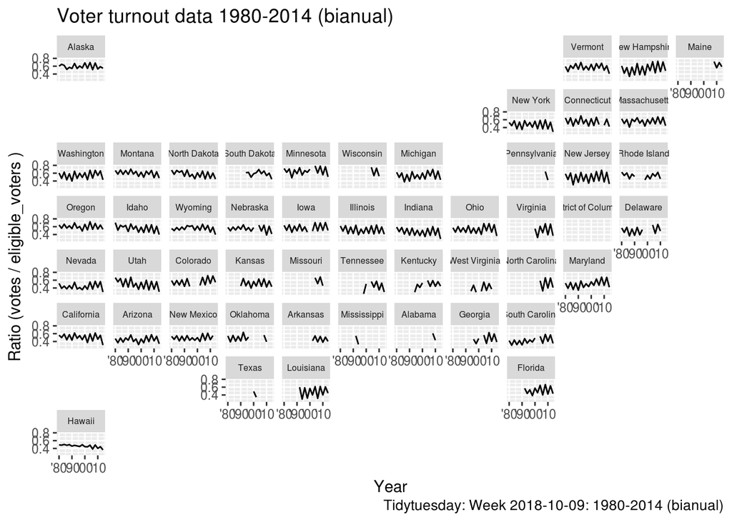

### Model

–

## Communicate

its quite easy to make the map. also have a huge amount of differente grids + a grid designer. awsome to take into acount for future works.

### learnt:

geofacet depends on sf, sf depends on gdal , gdal need version 2. https://github.com/r-spatial/sf

also : libmysqlclient-dev its needed by gdal, and not in the line of sf. added the issue to add the lib on the redme: https://github.com/r-spatial/sf/issues/862

if something goes wrong on linux packages: broken pkg on linux: https://unix.stackexchange.com/questions/389156/how-to-fix-held-broken-packages